# EPFL Extension School, Elements of Data Science, Project 1

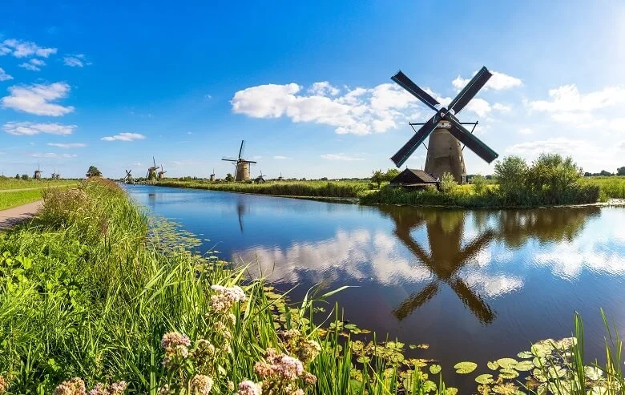

Course: Elements of Data Science  
Institute: EPFL Extension School  
Project Title: Project 1  
Author: Elo Ogbokor  
Learner Name: mediumorchid-tangerine  
Date: 05 July 2024

### Project Description:

Analysing data collected from a survey of participants at a conference in the Netherlands using survey.csv dataset through a series of exercises.

## Part 1

#### Importing survey.csv

**Load the data, make sure you have clean column names and answer the following questions:**

Before tackling the exercises, the survey data-set is required to be imported.

Loading the dataset, plus ensuring columns are clean.

Below is the survey.csv dataset containing the results from a survey of participants at a conference in the Netherlands. Each row stands for one participant.

```r
#Importing the survey.csv data-set
original_survey.csv <- read_csv("/Users/sunshine_in_a_bag/Documents/Adaire/Elements of Data Science/Project 1/data/survey.csv")
```

[output not shown]

```r
#When i open survey.csv, the first column is title "1," and contains a number assigned to each row. Since this column is unnecessary, use code below to evaporate the first column using select, plus -1. Since the column is title 1 by R, however blank is excel or Numbers, add - in front of the column-name "1" to eliminate the column.
#survey.csv is re-assigned to remove the first unnecessary column
survey.csv <- select(original_survey.csv, -1)


survey.csv
```

| University | Position | Number of employees | Number of PhD students | Number of postdocs | Number of professors | Sizes |
| --- | --- | --- | --- | --- | --- | --- |
| Delft University of Technology | PhD Student | 15 | 4 | 6 | 5 | Small (1 to 20) |
| Eindhoven University of Technology | Head of department | 20 | 8 | 2 | 10 | Small (1 to 20) |
| Eindhoven University of Technology | Professor | 10 | 3 | 1 | 6 | Small (1 to 20) |
| Delft University of Technology | Assistant Professor | 191 | 120 | 47 | 24 | Extra large(over 200) |
| Delft University of Technology | Assistant Professor | 34 | 20 | 10 | 4 | Medium (20 to 50) |
| University of Groningen | Associate Professor | 79 | 33 | 13 | 33 | Medium (20 to 50) |
| University of Groningen | Head of graduate studies | 71 | 34 | 16 | 21 | Large (50 to 200) |
| Leiden University | Postdoc | 75 | 42 | 21 | 12 | Large (50 to 200) |
| Delft University of Technology | Postdoc | 54 | 28 | 14 | 12 | Large (50 to 200) |
| Delft University of Technology | Postdoc | 10 | 2 | 3 | 5 | Small (1 to 20) |

[output cut: 20 more lines]

**Part 1, Question 1**

**How many survey participants were there? Show that you can find with code the number of lines in this dataset, since each line is one participant**

**Steps to reach Answer to Part 1, Question 1**

```r
survey.csv  %>%
  #Using nrow to determine number of rows (in other words, number of participants, since each line stands for one participant)
nrow()
```

```
## [1] 30
```

**Answer to Part 1, Question 1**

There were 30 survey participants.

**Part 1, Question 2**

**What are the data types of each column? Show that you know at least one function that will show in its output the type of each column**

**Steps to reach Answer to Part 1, Question 2**

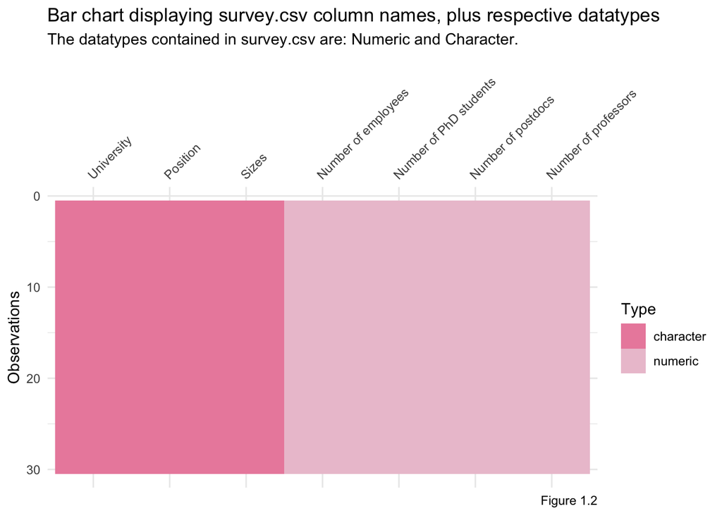

```r
#Plotting chart to display column names, plus indicate their datatypes.
vis_dat(survey.csv) +
  labs(title = "Bar chart displaying survey.csv column names, plus respective datatypes",
       subtitle = "The datatypes contained in survey.csv are: Numeric and Character.",
       caption = "Figure 1.2") +
   scale_fill_manual(values = c("#EB8DAB",
                             "#ECC4D3"
   ))
```

**Answer to Part 1, Question 2**

As viewed in Figure 1.2 above, the datatypes contained in survey.csv are:

- Numeric
- Character

The columns classified under *Numeric* are:

- Number of employees
- Number of PhD students
- Number of postdocs
- Number of professors

The columns classified under *Character* are:

- University
- Position
- Sizes

**Part 1, Question 3**

*What are the top 3 universities with the most survey participants? Show that you know how to compute some summary values on a dataset and extract only the lines that interest you from the result*

**Steps to reach Answer to Part 1, Question 3**

```r
 addColumnWithTotalParticipantsperUniversity <- survey.csv  %>%

  group_by(University)  %>%

  #number of rows per university = number of participants per university, since one row is one participant

  mutate(TotalParticipantsperUniversity = n())  %>%
  #n() for number of rows
#If we count the number of rows per university, we will have the total participants per university

  ungroup() #Do not forget un-grouping practice


  #count university entries

addColumnWithTotalParticipantsperUniversity
```

| University | Position | Number of employees | Number of PhD students | Number of postdocs | Number of professors | Sizes | TotalParticipantsperUniversity |
| --- | --- | --- | --- | --- | --- | --- | --- |
| Delft University of Technology | PhD Student | 15 | 4 | 6 | 5 | Small (1 to 20) | 9 |
| Eindhoven University of Technology | Head of department | 20 | 8 | 2 | 10 | Small (1 to 20) | 7 |
| Eindhoven University of Technology | Professor | 10 | 3 | 1 | 6 | Small (1 to 20) | 7 |
| Delft University of Technology | Assistant Professor | 191 | 120 | 47 | 24 | Extra large(over 200) | 9 |
| Delft University of Technology | Assistant Professor | 34 | 20 | 10 | 4 | Medium (20 to 50) | 9 |
| University of Groningen | Associate Professor | 79 | 33 | 13 | 33 | Medium (20 to 50) | 6 |
| University of Groningen | Head of graduate studies | 71 | 34 | 16 | 21 | Large (50 to 200) | 6 |
| Leiden University | Postdoc | 75 | 42 | 21 | 12 | Large (50 to 200) | 3 |
| Delft University of Technology | Postdoc | 54 | 28 | 14 | 12 | Large (50 to 200) | 9 |
| Delft University of Technology | Postdoc | 10 | 2 | 3 | 5 | Small (1 to 20) | 9 |

[output cut: 20 more lines]

Below we extract the columns (University, plus TotalParticipantsperUniversity) to only view the necessary content.

```r
viewUniversityandTotalParticipants <- addColumnWithTotalParticipantsperUniversity   %>%
  select(University, TotalParticipantsperUniversity)

viewUniversityandTotalParticipants
```

| University | TotalParticipantsperUniversity |
| --- | --- |
| Delft University of Technology | 9 |
| Eindhoven University of Technology | 7 |
| Eindhoven University of Technology | 7 |
| Delft University of Technology | 9 |
| Delft University of Technology | 9 |
| University of Groningen | 6 |
| University of Groningen | 6 |
| Leiden University | 3 |
| Delft University of Technology | 9 |
| Delft University of Technology | 9 |

[output cut: 20 more lines]

```r
NewColumnofOnlyTotalParticipants <-
viewUniversityandTotalParticipants  %>%
  summarise(TotalParticipantsAppearOnce = unique(TotalParticipantsperUniversity))
#unique to remove duplicates


NewColumnofOnlyTotalParticipants
```

| TotalParticipantsAppearOnce |
| --- |
| 9 |
| 7 |
| 6 |
| 3 |
| 5 |

```r
#summarise only returns new column, unlike mutate
```

```r
#Attempt to append university to total participants
  survey.csv  %>%
  group_by(University)  %>%
  summarise()  %>%
  #creating table where universities appear only once

  #mutate to append the totalparticipants column created using summarise to the universities
  mutate(NewColumnofOnlyTotalParticipants )  %>%

  arrange(desc(NewColumnofOnlyTotalParticipants ))
```

[output not shown]

```r
#sort participants in descending order, since we're seeking the highest values
```

**Answer to Part 1, Question 3**